# Getting Started with NHANES in R: Data Structure, Data wrangling, and Visualizations

TTS Research Technology

July 30, 2026

# 1 Before the Workshop

Please install R first, then RStudio Desktop.

- R: https://cran.r-project.org/
- RStudio Desktop: https://docs.posit.co/ide/user/#rstudio-ide-oss-downloads

After installation, open RStudio and confirm that you can open this file:

```
code/nhanes_workshop_demo.Rmd
```

During the live workshop, you can either type along in a fresh R Markdown file or follow this completed handout. If you are new to R, following this handout is recommended.

An R Markdown (`.Rmd`) file is helpful for workshops because it keeps the narrative, code, and output in one place. It is excellent for R-based reports, works smoothly in the mature RStudio ecosystem, and is especially useful when your analysis combines statistics, tables, and `ggplot2` figures.

# 2 What We Will Practice

By the end of the session, you should be able to:

1. Describe how NHANES public-use files are organized by cycle and file family.
2. Explain why CDC documentation/codebooks are part of the dataset.
3. Use a relative path to import local NHANES `.XPT` files from `data/raw`.
4. Join participant-level files with the shared identifier `SEQN`.
5. Make two basic `ggplot2` figures from joined NHANES data.
6. Save a figure with `ggsave()`.
7. Recognize when NHANES survey design variables matter for later analysis.

This workshop teaches workflow. It does not teach full survey-weighted NHANES analysis.

# 3 Workshop Folder

The folders are already created before class, so we will not create them in code during the demo.

```
NHANES_workshop/
  data/
    raw/            # untouched downloaded XPT files
    processed/      # joined or cleaned analysis files
  code/             # Rmd code file
  docs/
    documentation/  # CDC documentation and codebooks
  outputs/
    figures/        # saved plots
```

Important habit: keep raw files unchanged. Put cleaned or joined data in `data/processed`.

# 4 RStudio Orientation

In RStudio, you will usually use four panes:

- Source pane: where this R Markdown file opens.
- Console: where R runs commands and shows errors or messages.
- Environment: where created objects appear, such as `demo_data` or `nhanes_clean`.
- Files/Plots: where you can find project files and view figures.

For this workshop, the R Markdown file is useful because it keeps explanation, code, output, and notes together. A plain R script is also fine later, but the Rmd handout is better for a beginner workshop because you can easily revisit the steps after the workshop.

# 5 Packages

We need two packages for the live demo:

- `tidyverse`: includes [`dplyr`](https://dplyr.tidyverse.org/) for data wrangling, [`readr`](https://readr.tidyverse.org/) for CSV files, and [`ggplot2`](https://ggplot2.tidyverse.org/) for plotting.
- `haven`: imports SAS transport files (`.XPT`) with `read_xpt()`.

If you have never installed these packages, run this chunk once. If the packages are already installed, R will tell you.

```r
install.packages("tidyverse")
install.packages("haven")
```

For future reference, `pacman` is a package-management helper. `p_load()` installs missing packages and then loads them. We will not rely on `pacman` in this workshop, but you may see it in other R projects.

```r
install.packages("pacman")
pacman::p_load(tidyverse, haven)
```

Package websites:

- `tidyverse`: https://www.tidyverse.org/
- `haven`: https://haven.tidyverse.org/
- `pacman`: https://cran.r-project.org/package=pacman

For today, we will load the packages directly:

```r
library(tidyverse)
library(haven)
```

# 6 Common R Symbols

These symbols appear often in beginner R code.

| Symbol | What it means | Example |
| --- | --- | --- |
| `<-` | Assign/save an object name | `demo_data <- read_xpt(...)` |
| `%>%` | Pipe: then do the next step | `demo_data %>% select(SEQN)` |
| `#` | Comment; R ignores this text | `# check the first rows` |
| `+` | Add a layer to a ggplot | `ggplot(...) + geom_point()` |
| `==` | Test whether values are equal | `RIAGENDR == 1` |
| `"` | Text/file names need quotes | `"DEMO_J.xpt"` |

# 7 Relative Paths

This R Markdown file lives in the `code` folder. The `..` below means “go up one folder” to the main workshop folder.

```r
relative_path <- "../data/raw"
processed_path <- "../data/processed"
figure_path <- "../outputs/figures"

relative_path
```

```
## [1] "../data/raw"
```

Use `file.path()` instead of typing a long path by hand.

```r
file.path(relative_path, "DEMO_J.xpt")
```

```
## [1] "../data/raw/DEMO_J.xpt"
```

Read this as:

```
Go from code folder -> up to NHANES_workshop -> data -> raw -> DEMO_J.xpt
```

# 8 NHANES Files for Today

The workshop folder already contains three NHANES 2017-2018 `.XPT` files in `data/raw`.

| File | File family | What we use it for | CDC page |
| --- | --- | --- | --- |
| `DEMO_J.xpt` | Demographics | age, sex, race/ethnicity, survey design variables | [DEMO_J documentation](https://wwwn.cdc.gov/nchs/data/nhanes/public/2017/datafiles/DEMO_J.htm) |
| `BMX_J.xpt` | Examination | weight, height, body mass index | [BMX_J documentation](https://wwwn.cdc.gov/Nchs/Data/Nhanes/Public/2017/DataFiles/BMX_J.htm) |
| `DR1TOT_J.xpt` | Dietary | Day 1 total energy and protein intake | [DR1TOT_J documentation](https://wwwn.cdc.gov/Nchs/Data/Nhanes/Public/2017/DataFiles/DR1TOT_J.htm) |

In a real project, download both the `.XPT` file and the CDC documentation/codebook for each file you use. The codebook tells you variable names, labels, eligibility rules, and missing-value codes. You can practice downloading files from the [2017-2018 NHANES data page](https://wwwn.cdc.gov/nchs/nhanes/search/DataPage.aspx?Cycle=2017-2018).

# 9 Import Local XPT Files

`read_xpt()` imports NHANES `.XPT` files into R.

Common import functions:

| File type | Example file extension | R function | Package |
| --- | --- | --- | --- |
| SAS transport | `.xpt` | `read_xpt("file.xpt")` | `haven` |
| SAS dataset | `.sas7bdat` | `read_sas("file.sas7bdat")` | `haven` |
| Stata dataset | `.dta` | `read_dta("file.dta")` | `haven` |
| SPSS dataset | `.sav` | `read_sav("file.sav")` | `haven` |
| CSV text file | `.csv` | `read_csv("file.csv")` | `readr` / `tidyverse` |
| Excel workbook | `.xlsx` | `read_excel("file.xlsx")` | [`readxl`](https://readxl.tidyverse.org/) |

Python users will often see similar workflows with `pandas`, such as `pd.read_sas("file.xpt")`, `pd.read_csv("file.csv")`, `pd.read_stata("file.dta")`, and `pd.read_excel("file.xlsx")`.

```r
demo_data <- read_xpt(file.path(relative_path, "DEMO_J.xpt"))
bmx_data <- read_xpt(file.path(relative_path, "BMX_J.xpt"))
diet_data <- read_xpt(file.path(relative_path, "DR1TOT_J.xpt"))
```

Check that each object imported correctly.

```r
head(demo_data, n = 5)
```

```
## # A tibble: 5 × 46
##    SEQN SDDSRVYR RIDSTATR RIAGENDR RIDAGEYR RIDAGEMN RIDRETH1 RIDRETH3 RIDEXMON
##   <dbl>    <dbl>    <dbl>    <dbl>    <dbl>    <dbl>    <dbl>    <dbl>    <dbl>
## 1 93703       10        2        2        2       NA        5        6        2
## 2 93704       10        2        1        2       NA        3        3        1
## 3 93705       10        2        2       66       NA        4        4        2
## 4 93706       10        2        1       18       NA        5        6        2
## 5 93707       10        2        1       13       NA        5        7        2
## # ℹ 37 more variables: RIDEXAGM <dbl>, DMQMILIZ <dbl>, DMQADFC <dbl>,
## #   DMDBORN4 <dbl>, DMDCITZN <dbl>, DMDYRSUS <dbl>, DMDEDUC3 <dbl>,
## #   DMDEDUC2 <dbl>, DMDMARTL <dbl>, RIDEXPRG <dbl>, SIALANG <dbl>,
## #   SIAPROXY <dbl>, SIAINTRP <dbl>, FIALANG <dbl>, FIAPROXY <dbl>,
## #   FIAINTRP <dbl>, MIALANG <dbl>, MIAPROXY <dbl>, MIAINTRP <dbl>,
## #   AIALANGA <dbl>, DMDHHSIZ <dbl>, DMDFMSIZ <dbl>, DMDHHSZA <dbl>,
## #   DMDHHSZB <dbl>, DMDHHSZE <dbl>, DMDHRGND <dbl>, DMDHRAGZ <dbl>, …
```

```r
head(bmx_data, n = 5)
```

```
## # A tibble: 5 × 21
##    SEQN BMDSTATS BMXWT BMIWT BMXRECUM BMIRECUM BMXHEAD BMIHEAD BMXHT BMIHT
##   <dbl>    <dbl> <dbl> <dbl>    <dbl>    <dbl>   <dbl>   <dbl> <dbl> <dbl>
## 1 93703        1  13.7     3     89.6       NA      NA      NA  88.6    NA
## 2 93704        1  13.9    NA     95         NA      NA      NA  94.2    NA
## 3 93705        1  79.5    NA     NA         NA      NA      NA 158.     NA
## 4 93706        1  66.3    NA     NA         NA      NA      NA 176.     NA
## 5 93707        1  45.4    NA     NA         NA      NA      NA 158.     NA
## # ℹ 11 more variables: BMXBMI <dbl>, BMXLEG <dbl>, BMILEG <dbl>, BMXARML <dbl>,
## #   BMIARML <dbl>, BMXARMC <dbl>, BMIARMC <dbl>, BMXWAIST <dbl>,
## #   BMIWAIST <dbl>, BMXHIP <dbl>, BMIHIP <dbl>
```

```r
head(diet_data, n = 5)
```

```
## # A tibble: 5 × 168
##    SEQN WTDRD1 WTDR2D DR1DRSTZ DR1EXMER DRABF DRDINT DR1DBIH DR1DAY DR1LANG
##   <dbl>  <dbl>  <dbl>    <dbl>    <dbl> <dbl>  <dbl>   <dbl>  <dbl>   <dbl>
## 1 93703     0     NA         5       NA    NA     NA      NA     NA      NA
## 2 93704 81714. 82443.        1       49     2      2       7      2       1
## 3 93705  7186.  5640.        1       73     2      2       5      1       1
## 4 93706  6464.     0         1       86     2      1      NA      6       1
## 5 93707 15334. 22707.        1       81     2      2      14      2       1
## # ℹ 158 more variables: DR1MRESP <dbl>, DR1HELP <dbl>, DBQ095Z <dbl>,
## #   DBD100 <dbl>, DRQSPREP <dbl>, DR1STY <dbl>, DR1SKY <dbl>, DRQSDIET <dbl>,
## #   DRQSDT1 <dbl>, DRQSDT2 <dbl>, DRQSDT3 <dbl>, DRQSDT4 <dbl>, DRQSDT5 <dbl>,
## #   DRQSDT6 <dbl>, DRQSDT7 <dbl>, DRQSDT8 <dbl>, DRQSDT9 <dbl>, DRQSDT10 <dbl>,
## #   DRQSDT11 <dbl>, DRQSDT12 <dbl>, DRQSDT91 <dbl>, DR1TNUMF <dbl>,
## #   DR1TKCAL <dbl>, DR1TPROT <dbl>, DR1TCARB <dbl>, DR1TSUGR <dbl>,
## #   DR1TFIBE <dbl>, DR1TTFAT <dbl>, DR1TSFAT <dbl>, DR1TMFAT <dbl>, …
```

Use `glimpse()` when you want a compact list of variable names and types. To keep the handout readable, this example shows only a few demographic variables.

```r
demo_data %>%
  select(SEQN, RIDAGEYR, RIAGENDR, WTINT2YR, WTMEC2YR, SDMVSTRA, SDMVPSU) %>%
  glimpse()
```

```
## Rows: 9,254
## Columns: 7
## $ SEQN     <dbl> 93703, 93704, 93705, 93706, 93707, 93708, 93709, 93710, 93711…
## $ RIDAGEYR <dbl> 2, 2, 66, 18, 13, 66, 75, 0, 56, 18, 67, 54, 71, 61, 22, 45, …
## $ RIAGENDR <dbl> 2, 1, 2, 1, 1, 2, 2, 2, 1, 1, 1, 2, 1, 1, 1, 1, 2, 2, 2, 2, 1…
## $ WTINT2YR <dbl> 9246.492, 37338.768, 8614.571, 8548.633, 6769.345, 13329.451,…
## $ WTMEC2YR <dbl> 8539.731, 42566.615, 8338.420, 8723.440, 7064.610, 14372.489,…
## $ SDMVSTRA <dbl> 145, 143, 145, 134, 138, 138, 136, 134, 134, 147, 140, 147, 1…
## $ SDMVPSU  <dbl> 2, 1, 2, 2, 1, 2, 1, 1, 2, 2, 1, 1, 2, 1, 1, 1, 1, 1, 2, 1, 1…
```

Common tibble/R data types:

| Type shown by `glimpse()` | What it usually means | Example |
| --- | --- | --- |
| `<dbl>` | Numeric value stored as a double | age, BMI, kcal |
| `<int>` | Numeric value stored as an integer | counts, whole-number codes |
| `<chr>` | Character/text | names, labels, open text |
| `<fct>` | Factor/category with levels | recoded groups |
| `<date>` | Calendar date | interview date |
| `<dttm>` | Date-time | timestamp |
| `<lgl>` | Logical TRUE/FALSE | yes/no indicators |

Pause and check:

- Which file contains demographics?
- Which file contains BMI?
- Which file contains dietary intake?

# 10 Check the Join Key

Most participant-level NHANES files use `SEQN` as the respondent identifier. Before joining, check whether each file has one row per `SEQN`.

```r
demo_data %>%
  count(SEQN) %>%
  filter(n > 1)
```

```
## # A tibble: 0 × 2
## # ℹ 2 variables: SEQN <dbl>, n <int>
```

```r
bmx_data %>%
  count(SEQN) %>%
  filter(n > 1)
```

```
## # A tibble: 0 × 2
## # ℹ 2 variables: SEQN <dbl>, n <int>
```

```r
diet_data %>%
  count(SEQN) %>%
  filter(n > 1)
```

```
## # A tibble: 0 × 2
## # ℹ 2 variables: SEQN <dbl>, n <int>
```

If no rows are printed, this demo has no duplicate `SEQN` values in these files.

# 11 Select Variables for the Demo

Selecting fewer variables makes the joined dataset easier to inspect. We will keep the variables used later for plotting and missing-value checks. Survey weight variables are important for real NHANES estimates, but they are not used in this short visualization demo.

```r
demo_small <- demo_data %>%
  select(SEQN, RIDAGEYR, RIAGENDR)

bmx_small <- bmx_data %>%
  select(SEQN, BMXBMI)

diet_small <- diet_data %>%
  select(SEQN, DR1TKCAL)
```

Check missing values before the join:

```r
missing_before_join <- bind_rows(
  demo_small %>%
    summarize(across(everything(), ~ sum(is.na(.)))) %>%
    mutate(file = "DEMO_J"),
  bmx_small %>%
    summarize(across(everything(), ~ sum(is.na(.)))) %>%
    mutate(file = "BMX_J"),
  diet_small %>%
    summarize(across(everything(), ~ sum(is.na(.)))) %>%
    mutate(file = "DR1TOT_J")
) %>%
  relocate(file)

missing_before_join
```

```
## # A tibble: 3 × 6
##   file      SEQN RIDAGEYR RIAGENDR BMXBMI DR1TKCAL
##   <chr>    <int>    <int>    <int>  <int>    <int>
## 1 DEMO_J       0        0        0     NA       NA
## 2 BMX_J        0       NA       NA    699       NA
## 3 DR1TOT_J     0       NA       NA     NA     1220
```

# 12 dplyr Translation Table

`dplyr` website: https://dplyr.tidyverse.org/

These are common `dplyr` verbs mapped to Stata and Python/pandas habits.

| Task | R / dplyr | Stata mental model | Python / pandas |
| --- | --- | --- | --- |
| Keep variables | select(SEQN, RIDAGEYR, BMXBMI) | keep SEQN RIDAGEYR BMXBMI | df[["SEQN", "RIDAGEYR", "BMXBMI"]] |
| Filter rows | `filter(RIDAGEYR >= 20)` | keep if RIDAGEYR >= 20 | `df[df["RIDAGEYR"] >= 20]` |
| Create variable | mutate(adult = RIDAGEYR >= 20) | gen adult = RIDAGEYR >= 20 | df.assign(adult = df["RIDAGEYR"] >= 20) |
| Recode variable | case_when(RIAGENDR == 1 ~ "Male") | recode RIAGENDR (1 = 1 "Male") | np.select(...) or .map(...) |
| Group summary | group_by(sex) %>% summarize(n = n()) | collapse (count) n = SEQN, by(sex) | df.groupby(“sex”) .size() |
| Merge files | left_join(bmx, by = "SEQN") | merge 1:1 SEQN using bmx | df.merge(bmx, on = "SEQN", how = "left") |
| Append cycles | bind_rows(cycle1, cycle2) | append using cycle2 | pd.concat([cycle1, cycle2], ignore_index=True) |

# 13 Join Tables

Use `left_join()` to add columns from one participant-level file to another.

```r
nhanes_joined <- demo_small %>%
  left_join(bmx_small, by = "SEQN") %>%
  left_join(diet_small, by = "SEQN")

glimpse(nhanes_joined)
```

```
## Rows: 9,254
## Columns: 5
## $ SEQN     <dbl> 93703, 93704, 93705, 93706, 93707, 93708, 93709, 93710, 93711…
## $ RIDAGEYR <dbl> 2, 2, 66, 18, 13, 66, 75, 0, 56, 18, 67, 54, 71, 61, 22, 45, …
## $ RIAGENDR <dbl> 2, 1, 2, 1, 1, 2, 2, 2, 1, 1, 1, 2, 1, 1, 1, 1, 2, 2, 2, 2, 1…
## $ BMXBMI   <dbl> 17.5, 15.7, 31.7, 21.5, 18.1, 23.7, 38.9, NA, 21.3, 19.7, 23.…
## $ DR1TKCAL <dbl> NA, 1230, 1202, 1987, 1775, 1251, NA, 900, 2840, 2045, 2040, …
```

The joined dataset now contains demographic, body measure, and dietary variables in one table.

```r
row_counts <- tibble(
  table = c("demo_small", "bmx_small", "diet_small", "nhanes_joined"),
  rows = c(
    nrow(demo_small),
    nrow(bmx_small),
    nrow(diet_small),
    nrow(nhanes_joined)
  )
)

row_counts
```

```
## # A tibble: 4 × 2
##   table          rows
##   <chr>         <int>
## 1 demo_small     9254
## 2 bmx_small      8704
## 3 diet_small     8704
## 4 nhanes_joined  9254
```

Because we started with `demo_small` and used `left_join()`, the row count should match the demographic file. Some people appear in the demographic file but not in the body-measures or dietary files. After a left join, variables from those unmatched files become `NA`.

Check missing values after the join:

```r
nhanes_joined %>%
  summarize(across(everything(), ~ sum(is.na(.)))) %>%
  pivot_longer(
    cols = everything(),
    names_to = "variable",
    values_to = "missing_n"
  )
```

```
## # A tibble: 5 × 2
##   variable missing_n
##   <chr>        <int>
## 1 SEQN             0
## 2 RIDAGEYR         0
## 3 RIAGENDR         0
## 4 BMXBMI        1249
## 5 DR1TKCAL      1770
```

# 14 Save the Joined Dataset

Save a CSV copy in `data/processed` so students can open the file outside R if needed. `write_csv()` comes from `readr`, which is loaded with `tidyverse`.

```r
write_csv(nhanes_joined, file.path(processed_path, "nhanes_joined_demo.csv"))
```

# 15 Recode for Readability

NHANES often stores categories as numbers. The codebook tells us how to interpret those numeric codes. `haven::read_xpt()` can preserve variable labels from SAS files, but analysis and plotting are usually clearer when we explicitly recode important numeric categories into readable variables.

For this example:

- `RIAGENDR == 1` means Male.
- `RIAGENDR == 2` means Female.

BMI group is different. `BMXBMI` is the measured BMI value in the body-measures file; the BMI groups below are analyst-created categories for teaching and visualization. The fixed cut points shown here are adult BMI cut points. For children and teens, BMI categories should use age- and sex-specific BMI-for-age percentiles rather than these fixed adult cut points.

```r
nhanes_clean <- nhanes_joined %>%
  mutate(
    sex = case_when(
      RIAGENDR == 1 ~ "Male",
      RIAGENDR == 2 ~ "Female",
      TRUE ~ NA_character_
    ),
    bmi_group = case_when(
      is.na(BMXBMI) ~ NA_character_,
      BMXBMI < 18.5 ~ "Underweight",
      BMXBMI >= 18.5 & BMXBMI < 25 ~ "Healthy weight",
      BMXBMI >= 25 & BMXBMI < 30 ~ "Overweight",
      BMXBMI >= 30 ~ "Obesity"
    ),
    bmi_group = factor(
      bmi_group,
      levels = c("Underweight", "Healthy weight", "Overweight", "Obesity")
    ),
    age_group = case_when(
      is.na(RIDAGEYR) ~ NA_character_,
      RIDAGEYR < 40 ~ "Younger than 40",
      RIDAGEYR >= 40 & RIDAGEYR < 60 ~ "40 to 59",
      RIDAGEYR >= 60 ~ "60 or older"
    )
  )

nhanes_clean %>%
  select(SEQN, RIDAGEYR, age_group, sex, BMXBMI, bmi_group, DR1TKCAL)
```

```
## # A tibble: 9,254 × 7
##     SEQN RIDAGEYR age_group       sex    BMXBMI bmi_group      DR1TKCAL
##    <dbl>    <dbl> <chr>           <chr>   <dbl> <fct>             <dbl>
##  1 93703        2 Younger than 40 Female   17.5 Underweight          NA
##  2 93704        2 Younger than 40 Male     15.7 Underweight        1230
##  3 93705       66 60 or older     Female   31.7 Obesity            1202
##  4 93706       18 Younger than 40 Male     21.5 Healthy weight     1987
##  5 93707       13 Younger than 40 Male     18.1 Underweight        1775
##  6 93708       66 60 or older     Female   23.7 Healthy weight     1251
##  7 93709       75 60 or older     Female   38.9 Obesity              NA
##  8 93710        0 Younger than 40 Female   NA   <NA>                900
##  9 93711       56 40 to 59        Male     21.3 Healthy weight     2840
## 10 93712       18 Younger than 40 Male     19.7 Healthy weight     2045
## # ℹ 9,244 more rows
```

Use `glimpse()` again to see how the new character and factor variables differ from the original numeric variables.

```r
glimpse(nhanes_clean %>% select(SEQN, RIDAGEYR, age_group, sex, BMXBMI, bmi_group, DR1TKCAL))
```

```
## Rows: 9,254
## Columns: 7
## $ SEQN      <dbl> 93703, 93704, 93705, 93706, 93707, 93708, 93709, 93710, 9371…
## $ RIDAGEYR  <dbl> 2, 2, 66, 18, 13, 66, 75, 0, 56, 18, 67, 54, 71, 61, 22, 45,…
## $ age_group <chr> "Younger than 40", "Younger than 40", "60 or older", "Younge…
## $ sex       <chr> "Female", "Male", "Female", "Male", "Male", "Female", "Femal…
## $ BMXBMI    <dbl> 17.5, 15.7, 31.7, 21.5, 18.1, 23.7, 38.9, NA, 21.3, 19.7, 23…
## $ bmi_group <fct> Underweight, Underweight, Obesity, Healthy weight, Underweig…
## $ DR1TKCAL  <dbl> NA, 1230, 1202, 1987, 1775, 1251, NA, 900, 2840, 2045, 2040,…
```

For more detail on BMI categories, see CDC’s [adult BMI categories](https://www.cdc.gov/bmi/adult-calculator/bmi-categories.html) and [child and teen BMI categories](https://www.cdc.gov/bmi/child-teen-calculator/bmi-categories.html).

# 16 Plot 1: BMI by Age

Before we make plots, it helps to know the basic idea behind `ggplot2`: start with a dataset, map variables to visual features such as x-position, y-position, or color, then add layers such as points, boxes, violins, labels, and themes. The examples below use `ggplot2` for quick data-checking visuals, not final publication graphics.

- `ggplot2` website: https://ggplot2.tidyverse.org/

This first plot is a data-checking plot. We are asking whether BMI values look plausible across age and whether there are missing or unusual values.

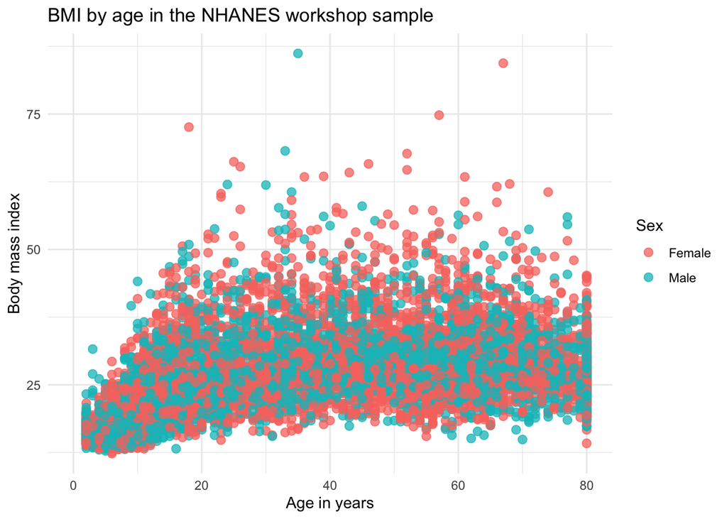

```r
bmi_age_plot <- ggplot(
  data = nhanes_clean,
  mapping = aes(x = RIDAGEYR, y = BMXBMI, color = sex)
) +
  geom_point(size = 2.5, alpha = 0.75) +
  labs(
    title = "BMI by age in the NHANES workshop sample",
    x = "Age in years",
    y = "Body mass index",
    color = "Sex"
  ) +
  theme_minimal()

bmi_age_plot
```

What to notice:

- Each point is one participant.
- `x = RIDAGEYR` puts age on the horizontal axis.
- `y = BMXBMI` puts BMI on the vertical axis.
- `color = sex` uses the recoded sex variable.
- `+` adds each ggplot layer.

Save the figure:

```r
ggsave(
  filename = file.path(figure_path, "bmi_by_age.png"),
  plot = bmi_age_plot,
  width = 7,
  height = 4.5,
  dpi = 300
)
```

# 17 Plot 2: Energy Intake by BMI Group

This plot uses variables from two joined file families:

- `BMXBMI` from the examination file.
- `DR1TKCAL` from the dietary file.

A violin plot shows the shape of the energy-intake distribution within each BMI group. The narrow boxplot inside the violin gives a familiar median-and-quartile summary.

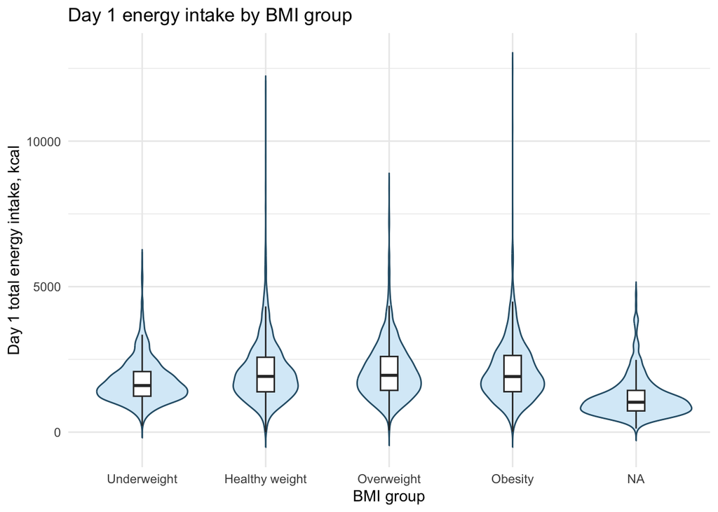

```r
energy_plot <- ggplot(
  data = nhanes_clean,
  mapping = aes(x = bmi_group, y = DR1TKCAL)
) +
  geom_violin(fill = "#D8ECF8", color = "#2C5D75", trim = FALSE, na.rm = TRUE) +
  geom_boxplot(width = 0.14, outlier.shape = NA, fill = "white", na.rm = TRUE) +
  labs(
    title = "Day 1 energy intake by BMI group",
    x = "BMI group",
    y = "Day 1 total energy intake, kcal"
  ) +
  theme_minimal()

energy_plot
```

Save the figure:

```r
ggsave(
  filename = file.path(figure_path, "energy_by_bmi_group.png"),
  plot = energy_plot,
  width = 7,
  height = 4.5,
  dpi = 300
)
```

Important interpretation reminder: this is an unweighted plot. It is useful for learning data structure and visualization, but it is not a population estimate.

# 18 In-Class Practice

Spend 8-10 minutes modifying the first plot.

Goal: create a new BMI-by-age plot that also shows BMI group and sex. The completed figure is included below so participants can compare their work with the target output.

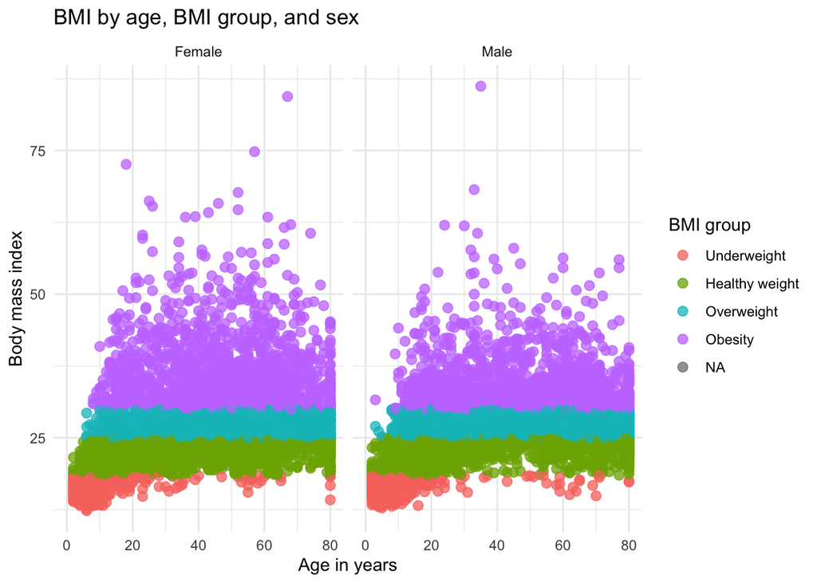

```r
practice_plot <- ggplot(
  data = nhanes_clean,
  mapping = aes(x = RIDAGEYR, y = BMXBMI, color = bmi_group)
) +
  geom_point(size = 2.5, alpha = 0.75) +
  facet_wrap(~ sex) +
  labs(
    title = "BMI by age, BMI group, and sex",
    x = "Age in years",
    y = "Body mass index",
    color = "BMI group"
  ) +
  theme_minimal()

practice_plot
```

```r
ggsave(
  filename = file.path(figure_path, "practice_bmi_by_age.png"),
  plot = practice_plot,
  width = 8,
  height = 4.5,
  dpi = 300
)
```

Write two notes below your plot:

1. One pattern you notice.
2. One reason this plot should not be treated as a final NHANES estimate.

# 19 Optional Summary Table

For quick descriptive tables, the `table1` package is useful. It is not required for the workshop, but it is a common way to create readable summary tables for reports and manuscripts.

- `table1` CRAN package page: https://cran.r-project.org/package=table1
- `table1` RDocumentation page: https://www.rdocumentation.org/packages/table1/versions/1.5.1

```r
library(table1)

table1(
  ~ RIDAGEYR + BMXBMI + DR1TKCAL | sex,
  data = nhanes_clean
)
```

|  | Female (N=4697) | Male (N=4557) | Overall (N=9254) |
| --- | --- | --- | --- |
| Age in years at screening |  |  |  |
| Mean (SD) | 34.5 (25.3) | 34.1 (25.8) | 34.3 (25.5) |
| Median [Min, Max] | 32.0 [0, 80.0] | 30.0 [0, 80.0] | 31.0 [0, 80.0] |
| Body Mass Index (kg/m**2) |  |  |  |
| Mean (SD) | 27.0 (8.80) | 26.2 (7.63) | 26.6 (8.26) |
| Median [Min, Max] | 25.8 [12.3, 84.4] | 25.8 [12.8, 86.2] | 25.8 [12.3, 86.2] |
| Missing | 589 (12.5%) | 660 (14.5%) | 1249 (13.5%) |
| Energy (kcal) |  |  |  |
| Mean (SD) | 1740 (780) | 2240 (1110) | 1990 (989) |
| Median [Min, Max] | 1620 [0, 7460] | 2040 [3.00, 12500] | 1810 [0, 12500] |
| Missing | 891 (19.0%) | 879 (19.3%) | 1770 (19.1%) |

The same idea can also be written with `dplyr`:

```r
nhanes_clean %>%
  group_by(sex, bmi_group) %>%
  summarize(
    mean_energy = mean(DR1TKCAL, na.rm = TRUE),
    mean_bmi = mean(BMXBMI, na.rm = TRUE),
    n = n(),
    .groups = "drop"
  )
```

```
## # A tibble: 10 × 5
##    sex    bmi_group      mean_energy mean_bmi     n
##    <chr>  <fct>                <dbl>    <dbl> <int>
##  1 Female Underweight          1656.     16.1   726
##  2 Female Healthy weight       1772.     21.9  1157
##  3 Female Overweight           1822.     27.4   912
##  4 Female Obesity              1821.     37.2  1313
##  5 Female <NA>                 1077.    NaN     589
##  6 Male   Underweight          1837.     16.2   723
##  7 Male   Healthy weight       2435.     22.0  1034
##  8 Male   Overweight           2338.     27.4  1045
##  9 Male   Obesity              2410.     35.5  1095
## 10 Male   <NA>                 1285.    NaN     660
```

# 20 Troubleshooting Checklist

When R returns an error, check these first:

1. Did you run `library(tidyverse)` and `library(haven)`?
2. Is the file in `data/raw`?
3. Did you spell the file name exactly, including capital letters?
4. Did you run the chunk that creates the object?
5. Are commas, quotes, and parentheses complete?
6. Did you use `+` to add ggplot layers?
7. If R says “object not found,” look in the Environment pane and rerun the earlier chunk.

# 21 Survey Design Reminder

NHANES is a complex survey. For descriptive population estimates, analyses usually require:

- the correct sample weight;
- strata;
- primary sampling units, or PSU.

The demographic file includes survey design variables such as `WTINT2YR`, `WTMEC2YR`, `SDMVSTRA`, and `SDMVPSU`. In the live demo, you can open the DEMO_J codebook and identify what each of these variables represents. You may learn more about survey-weighted estimation with packages such as `survey` or `srvyr`.

Helpful documentation:

- NHANES tutorials: https://wwwn.cdc.gov/nchs/nhanes/tutorials/default.aspx
- NHANES analytic guidelines: https://wwwn.cdc.gov/nchs/nhanes/analyticguidelines.aspx
- `survey` package documentation: https://cran.r-project.org/package=survey
- `srvyr` package documentation: https://cran.r-project.org/package=srvyr

# 22 Useful Links

- About NHANES: https://www.cdc.gov/nchs/nhanes/about/index.html
- NHANES datasets and documentation: https://wwwn.cdc.gov/nchs/nhanes/default.aspx
- Continuous NHANES: https://wwwn.cdc.gov/nchs/nhanes/continuousnhanes/
- NHANES tutorials: https://wwwn.cdc.gov/nchs/nhanes/tutorials/default.aspx
- Optional tidyverse learning resource: [R for Data Science, 2e](https://r4ds.hadley.nz)